© Bản quyền thuộc về Quantopian Inc.  
© Bản quyền sửa đổi thuộc về AI Cafe¹  
Giấy phép [Creative Commons Attribution 4.0](https://creativecommons.org/licenses/by/4.0/legalcode).  
[Khuyến cáo](https://aicafe.one/khuyen-cao/)

# Hồi quy tuyến tính bội (Multiple Linear Regression)

By Evgenia "Jenny" Nitishinskaya, Maxwell Margenot, Delaney Granizo-Mackenzie, and Gilbert Wasserman.

Edited by AI Cafe¹

```python
import numpy as np
import pandas as pd
import statsmodels.api as sm
# If the observations are in a dataframe, you can use statsmodels.formulas.api to do the regression instead
from statsmodels import regression
import matplotlib.pyplot as plt
```

Hồi quy tuyến tính đa biến tổng quát hóa hồi quy tuyến tính, cho phép biến phụ thuộc là một hàm tuyến tính của nhiều biến độc lập. Như trước đây, chúng ta giả định rằng biến $Y$ là một hàm tuyến tính của $X_1,\ldots, X_k$:

$$ Y_i = \beta_0 + \beta_1 X_{1i} + \ldots + \beta_k X_{ki} + \epsilon_i $$

Thường thì trong tài chính, dạng này sẽ được viết như sau, nhưng chỉ có tên biến thay đổi và mô hình thì vẫn giống nhau:

$$ Y_i = \alpha + \beta_1 X_{1i} + \ldots + \beta_k X_{ki} + \epsilon_i $$

Đối với các quan sát $i = 1,2,\ldots, n$. Để tìm mặt phẳng (hoặc siêu phẳng) phù hợp tốt nhất, chúng ta sẽ sử dụng phương pháp bình phương tối thiểu thông thường (OLS), phương pháp này tìm cách giảm thiểu sai số bình phương giữa các dự đoán và quan sát, $\sum_{i=1}^n \epsilon_i^2$. Việc bình phương làm cho sai số dương và âm đều xấu như nhau, và phóng đại các sai số lớn. Nó cũng tô lên vẻ đẹp của toán học ẩn dưới mô hình tuyến tính, nhưng chúng ta sẽ không đi sâu vào điều đó bây giờ. Để có một ví dụ về sai số bình phương, hãy xem phần sau.

Giả sử Y là dữ liệu thực tế của chúng ta, và Y_hat là những dự đoán được thực hiện bởi hồi quy tuyến tính.

```python
Y = np.array([1, 3.5, 4, 8, 12])
Y_hat = np.array([1, 3, 5, 7, 9])

print('Error ' + str(Y_hat - Y))

# Compute squared error
SE = (Y_hat - Y) ** 2

print('Squared Error ' + str(SE))
print('Sum Squared Error ' + str(np.sum(SE)))
```

```
Error [ 0.  -0.5  1.  -1.  -3. ]
Squared Error [0.   0.25 1.   1.   9.  ]
Sum Squared Error 11.25
```

Một khi chúng ta đã sử dụng phương pháp này để xác định các hệ số của hồi quy, chúng ta sẽ có khả năng sử dụng các giá trị quan sát mới của $X$ để dự đoán các giá trị của $Y$.

Chúng ta bắt đầu bằng cách xây dựng $Y$, $X_1$, và $X_2$ một cách nhân tạo trong đó chúng ta biết mối quan hệ chính xác giữa chúng.

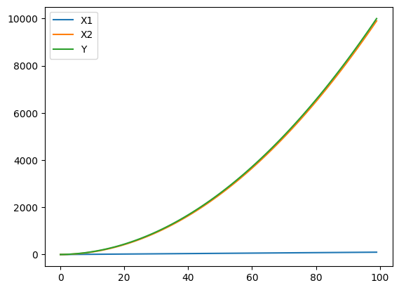

```python
# Construct a simple linear curve of 1, 2, 3, ...
X1 = np.arange(100)

# Make a parabola and add X1 to it, this is X2
X2 = np.array([i ** 2 for i in range(100)]) + X1

# This is our real Y, constructed using a linear combination of X1 and X2
Y = X1 + X2

plt.plot(X1, label='X1')
plt.plot(X2, label='X2')
plt.plot(Y, label='Y')
plt.legend();
```

Chúng ta có thể sử dụng cùng một hàm từ `statsmodels` như chúng ta đã làm trong bài giảng hồi quy tuyến tính đơn.

```python
# Use column_stack to combine independent variables, then add a column of ones so we can fit an intercept
X = sm.add_constant(np.column_stack((X1, X2)))

# Run the model
results = regression.linear_model.OLS(Y, X).fit()

print('Beta_0:', results.params[0])
print('Beta_1:', results.params[1])
print('Beta_2:', results.params[2])
```

```
Beta_0: 2.5579538487363607e-13
Beta_1: 1.0000000000004086
Beta_2: 0.9999999999999942
```

Cần phải chú ý đến những kết quả này giống như với các đạo hàm riêng. Công thức cho $Y$ có vẻ như là

$$X_1 + X_2 = X_1 + X^2 + X_1 = 2 X_1 + X^2$$

Hoặc $2X_1$ cộng với một parabol.

Tuy nhiên, hệ số của $X_1$ là 1. Điều này có nghĩa là $Y$ thay đổi 1 nếu chúng ta thay đổi $X_1$ thêm 1 *trong khi giữ $X_2$ không đổi*. Hồi quy tuyến tính nhiều biến tách biệt các đóng góp từ các biến khác nhau.

Tương tự, việc thực hiện hồi quy tuyến tính trên hai chứng khoán có thể cho ra một $\beta$ cao. Tuy nhiên, nếu chúng ta đưa vào một chứng khoán thứ ba (ví dụ: VNINDEX) như một biến độc lập, chúng ta có thể thấy rằng mối tương quan giữa hai chứng khoán đầu tiên hầu như hoàn toàn do cả hai đều có tương quan với VNINDEX. Điều này hữu ích vì VNINDEX có thể là một dự đoán đáng tin cậy hơn cho cả hai chứng khoán so với việc chúng dự đoán lẫn nhau. Phương pháp này cho phép chúng ta đánh giá tốt hơn mối liên quan giữa hai chứng khoán và ngăn chặn sự gây nhiễu giữa hai biến.

```python
# Cài thư viện lấy dữ liệu miễn phí
!curl -fsSLO https://raw.githubusercontent.com/algo-stocks/data/master/data.py
```

```python
from data import get_prices

start = '2024-01-01'
end = '2025-01-01'

prices = get_prices('VNINDEX', 'FPT', 'HPG', start_date=start, end_date=end)

asset1 = prices['FPT']
asset2 = prices['HPG']
benchmark = prices['VNINDEX']

# First, run a linear regression on the two assets
slr = regression.linear_model.OLS(asset1, sm.add_constant(asset2)).fit()
print('SLR beta of asset2:', slr.params.iloc[1])
```

```
SLR beta of asset2: 4.037404342324883
```

```python
# Run multiple linear regression using asset2 and VNINDEX as independent variables
mlr = regression.linear_model.OLS(asset1, sm.add_constant(np.column_stack((asset2, benchmark)))).fit()

prediction = mlr.params.iloc[0] + mlr.params.iloc[1]*asset2 + mlr.params.iloc[2]*benchmark
prediction.name = 'Prediction'

print('MLR beta of asset2:', mlr.params.iloc[1], '\nMLR beta of VNINDEX:', mlr.params.iloc[2])
```

```
MLR beta of asset2: -3.9717502152972997
MLR beta of VNINDEX: 0.44067110307103796
```

Bước tiếp theo sau khi thực hiện phân tích là xác định xem chúng ta có thể tin tưởng vào kết quả hay không. Một cách tốt để bắt đầu là kiểm tra xem có điều gì đó trông lạ trong biểu đồ của các biến độc lập, các biến phụ thuộc và dự đoán hay không.

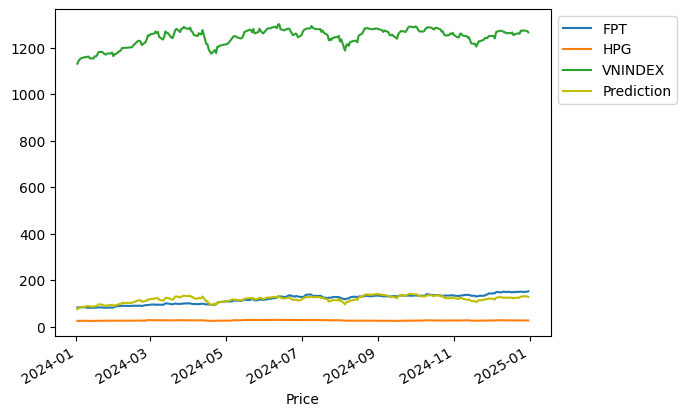

```python
# Plot the three variables along with the prediction given by the MLR
asset1.plot()
asset2.plot()
benchmark.plot()
prediction.plot(color='y')
plt.xlabel('Price')
plt.legend(bbox_to_anchor=(1,1), loc=2);
```

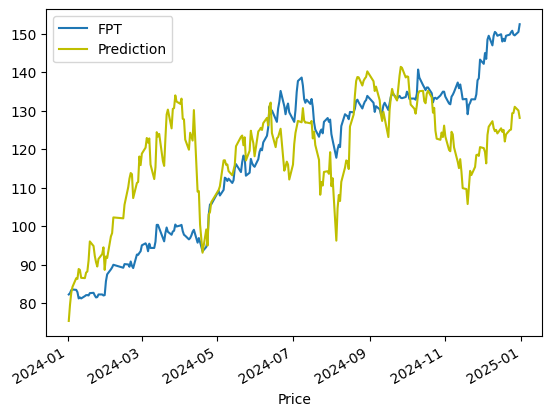

```python
# Plot only the dependent variable and the prediction to get a closer look
asset1.plot()
prediction.plot(color='y')
plt.xlabel('Price')
plt.legend();
```

## Đánh giá

Chúng ta có thể lấy một số thống kê về độ phù hợp từ kết quả trả về bởi hồi quy:

```python
mlr.summary()
```

OLS Regression Results

| Dep. Variable: | FPT | R-squared: | 0.450 |
| --- | --- | --- | --- |
| Model: | OLS | Adj. R-squared: | 0.445 |
| Method: | Least Squares | F-statistic: | 100.6 |
| Date: | Fri, 18 Apr 2025 | Prob (F-statistic): | 1.21e-32 |
| Time: | 02:23:05 | Log-Likelihood: | -1029.5 |
| No. Observations: | 249 | AIC: | 2065. |
| Df Residuals: | 246 | BIC: | 2076. |
| Df Model: | 2 |  |  |
| Covariance Type: | nonrobust |  |  |

|  | coef | std err | t | P>\|t\| | [0.025 | 0.975] |
| --- | --- | --- | --- | --- | --- | --- |
| const | -324.2389 | 32.691 | -9.918 | 0.000 | -388.629 | -259.849 |
| x1 | -3.9718 | 0.976 | -4.070 | 0.000 | -5.894 | -2.050 |
| x2 | 0.4407 | 0.033 | 13.157 | 0.000 | 0.375 | 0.507 |

| Omnibus: | 7.979 | Durbin-Watson: | 0.044 |
| --- | --- | --- | --- |
| Prob(Omnibus): | 0.019 | Jarque-Bera (JB): | 5.974 |
| Skew: | -0.265 | Prob(JB): | 0.0504 |
| Kurtosis: | 2.458 | Cond. No. | 4.24e+04 |

Notes:  
[1] Standard Errors assume that the covariance matrix of the errors is correctly specified.  
[2] The condition number is large, 4.24e+04. This might indicate that there are  
strong multicollinearity or other numerical problems.

## Giả định của Mô hình

Tính hợp lệ của các thống kê này phụ thuộc vào việc các giả định của mô hình hồi quy tuyến tính có được thỏa mãn hay không. Các giả định này bao gồm:

- Biến độc lập không phải là ngẫu nhiên.
- Phương sai của sai số là không đổi giữa các quan sát. Điều này rất quan trọng để đánh giá chất lượng của mô hình.
- Các sai số không có mối tương quan tự hồi quy. Thống kê Durbin-Watson được báo cáo bởi hồi quy phát hiện điều này. Nếu nó gần bằng $2$, thì không có tương quan tự hồi quy.
- Các sai số được phân phối theo phân phối chuẩn. Nếu điều này không đúng, chúng ta không thể sử dụng một số thống kê, chẳng hạn như kiểm tra F.

Hồi quy tuyến tính đa biến cũng yêu cầu một giả định bổ sung:

- Không có mối quan hệ tuyến tính chính xác giữa các biến độc lập. Nếu không, không thể giải cho các hệ số $\beta_i$ một cách duy nhất, vì cùng một phương trình tuyến tính có thể được biểu diễn theo nhiều cách khác nhau.

Nếu có một mối quan hệ tuyến tính giữa bất kỳ tập hợp nào của các biến độc lập, còn được gọi là hiệp phương sai, chúng ta nói rằng chúng là các tổ hợp tuyến tính của nhau. Trong trường hợp chúng phụ thuộc vào nhau theo cách này, giá trị của các hệ số $\beta_i$ của chúng ta sẽ không chính xác cho một $X_i$ nhất định. Trực giác cho điều này có thể được tìm thấy trong một ví dụ cực đoan, nơi $X_1$ và $X_2$ có hiệp phương sai 100%. Trong trường hợp đó, hồi quy tuyến tính có thể tương đương phân bổ tổng hợp hệ số theo bất kỳ tổ hợp nào mà không ảnh hưởng đến khả năng dự đoán.

$$ 1X_1 + 0X_2 = 0.5X_1 + 0.5X_2 = 0X_1 + 1X_2 $$

Mặc dù các hệ số của chúng ta có thể không mô tả rõ ràng, mô hình cuối cùng vẫn có thể chính xác miễn là có sự phù hợp tốt giữa các biến độc lập và các biến phụ thuộc. Thực tiễn tốt nhất để xây dựng một mô hình mà sự phụ thuộc là một vấn đề là loại bỏ các biến ít mô tả hơn có liên quan đến các biến tốt hơn. Điều này cải thiện mô hình bằng cách giảm cơ hội overfitting trong khi đưa các ước lượng $\beta_i$ gần hơn với giá trị thực của chúng.

Nếu chúng ta xác nhận rằng các giả định cần thiết của mô hình hồi quy đã được thỏa mãn, chúng ta có thể yên tâm sử dụng các thống kê được báo cáo để phân tích sự phù hợp. Ví dụ, giá trị $R^2$ cho biết phần trăm biến động tổng thể của $Y$ được mô hình giải thích. Tuy nhiên, khi thực hiện hồi quy tuyến tính đa biến, chúng ta ưa thích sử dụng $R^2$ điều chỉnh hơn, điều này sửa đổi cho những tăng nhỏ trong $R^2$ xảy ra khi chúng ta thêm nhiều biến hồi quy vào mô hình, ngay cả khi chúng không có mối tương quan đáng kể với biến phụ thuộc. $R^2$ điều chỉnh được định nghĩa là

$$ 1 - (1 - R^2)\frac{n-1}{n-k-1} $$

Trong đó $n$ là số lượng quan sát và $k$ là số lượng biến độc lập trong mô hình. Các thống kê hữu ích khác bao gồm thống kê F và sai số chuẩn của ước lượng.

## Ví dụ về Lựa Chọn Mô Hình

Khi quyết định mô hình tốt nhất cho các biến phụ thuộc của bạn, có nhiều phương pháp khác nhau để tham khảo. Nếu bạn sử dụng quá nhiều biến giải thích, bạn có nguy cơ làm quá khớp mô hình của mình, nhưng nếu bạn sử dụng quá ít, bạn có thể kết thúc với một mô hình không phù hợp. Một trong những phương pháp nổi bật nhất để xác định mô hình tốt nhất là hồi quy từng bước. Hồi quy từng bước bắt đầu từ một mô hình trống và kiểm tra từng biến riêng lẻ, chọn ra biến nào mang lại chất lượng mô hình tốt nhất, thường được đo bằng AIC hoặc BIC (giá trị thấp nhất là tốt nhất). Sau đó, nó thêm các biến còn lại từng cái một, kiểm tra từng tổ hợp biến giải thích tiếp theo trong hồi quy và tính toán giá trị AIC hoặc BIC ở mỗi bước. Cuối cùng của hồi quy, mô hình có chất lượng tốt nhất (theo thước đo đã cho) sẽ được chọn và trình bày như là mô hình tốt nhất cuối cùng. Tuy nhiên, điều này có những hạn chế. Nó không kiểm tra mọi tổ hợp biến có thể, vì vậy có thể bỏ lỡ mô hình lý thuyết tốt nhất nếu một biến nào đó đã bị loại bỏ sớm trong quá trình thực hiện thuật toán. Do đó, hồi quy từng bước nên được sử dụng kết hợp với phán đoán tốt nhất của bạn về mô hình.

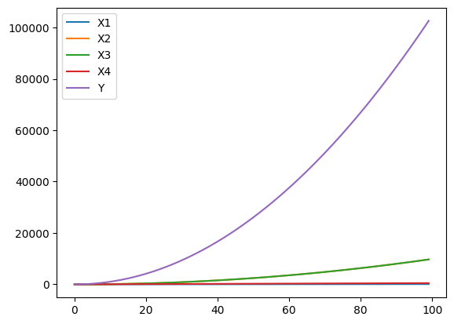

```python
X1 = np.arange(100)
X2 = [i**2 for i in range(100)] - X1
X3 = [np.log(i) for i in range(1, 101)] + X2
X4 = 5 * X1
Y = 2 * X1 + 0.5 * X2 + 10 * X3 + X4

plt.plot(X1, label='X1')
plt.plot(X2, label='X2')
plt.plot(X3, label='X3')
plt.plot(X4, label='X4')
plt.plot(Y, label='Y')
plt.legend();
```

```python
results = regression.linear_model.OLS(Y, sm.add_constant(np.column_stack((X1,X2,X3,X4)))).fit()

print("Beta_0:", results.params[0])
print("Beta_1:", results.params[1])
print("Beta_2:", results.params[2])
print("Beta_3:", results.params[3])
print("Beta_4:", results.params[4])
```

```
Beta_0: -2.4556356947869062e-11
Beta_1: 0.26923076923053646
Beta_2: 0.4999999999886313
Beta_3: 10.000000000009095
Beta_4: 1.3461538461538538
```

```python
data = pd.DataFrame(np.column_stack((X1,X2,X3,X4)), columns=['X1','X2','X3','X4'])
response = pd.Series(Y, name='Y')
```

```python
def forward_aic(response, data):
    # This function will work with pandas dataframes and series

    # Initialize some variables
    explanatory = list(data.columns)
    selected = pd.Series(np.ones(data.shape[0]), name="Intercept")
    current_score, best_new_score = np.inf, np.inf

    # Loop while we haven't found a better model
    while current_score == best_new_score and len(explanatory) != 0:

        scores_with_elements = []
        count = 0

        # For each explanatory variable
        for element in explanatory:
            # Make a set of explanatory variables including our current best and the new one
            tmp = pd.concat([selected, data[element]], axis=1)
            # Test the set
            result = regression.linear_model.OLS(Y, tmp).fit()
            score = result.aic
            scores_with_elements.append((score, element, count))
            count += 1

        # Sort the scoring list
        scores_with_elements.sort(reverse = True)
        # Get the best new variable
        best_new_score, best_element, index = scores_with_elements.pop()
        if current_score > best_new_score:
            # If it's better than the best add it to the set
            explanatory.pop(index)
            selected = pd.concat([selected, data[best_element]],axis=1)
            current_score = best_new_score
    # Return the final model
    model = regression.linear_model.OLS(Y, selected).fit()
    return model
```

```python
result = forward_aic(Y, data)
result.summary()
```

OLS Regression Results

| Dep. Variable: | y | R-squared: | 1.000 |
| --- | --- | --- | --- |
| Model: | OLS | Adj. R-squared: | 1.000 |
| Method: | Least Squares | F-statistic: | 1.260e+27 |
| Date: | Fri, 18 Apr 2025 | Prob (F-statistic): | 0.00 |
| Time: | 02:32:09 | Log-Likelihood: | 1770.9 |
| No. Observations: | 100 | AIC: | -3534. |
| Df Residuals: | 96 | BIC: | -3523. |
| Df Model: | 3 |  |  |
| Covariance Type: | nonrobust |  |  |

|  | coef | std err | t | P>\|t\| | [0.025 | 0.975] |
| --- | --- | --- | --- | --- | --- | --- |
| Intercept | 4.411e-11 | 3.47e-09 | 0.013 | 0.990 | -6.85e-09 | 6.94e-09 |
| X3 | 10.0000 | 2.1e-09 | 4.76e+09 | 0.000 | 10.000 | 10.000 |
| X1 | 0.2692 | 6.42e-12 | 4.19e+10 | 0.000 | 0.269 | 0.269 |
| X2 | 0.5000 | 2.1e-09 | 2.38e+08 | 0.000 | 0.500 | 0.500 |
| X4 | 1.3462 | 3.21e-11 | 4.19e+10 | 0.000 | 1.346 | 1.346 |

| Omnibus: | 14.005 | Durbin-Watson: | 0.001 |
| --- | --- | --- | --- |
| Prob(Omnibus): | 0.001 | Jarque-Bera (JB): | 9.998 |
| Skew: | 0.649 | Prob(JB): | 0.00674 |
| Kurtosis: | 2.155 | Cond. No. | 5.01e+17 |

Notes:  
[1] Standard Errors assume that the covariance matrix of the errors is correctly specified.  
[2] The smallest eigenvalue is 1.52e-26. This might indicate that there are  
strong multicollinearity problems or that the design matrix is singular.

Trong việc xây dựng mô hình này, biến $X_4$ có mối liên hệ rất chặt chẽ với biến $X_1$, đơn giản chỉ là nhân nó với một hằng số. Tuy nhiên, hồi quy từng bước không phát hiện ra điều này và đã không loại bỏ biến mà chỉ điều chỉnh hệ số của biến $X_1$. Theo phán đoán của chúng tôi, nên loại bỏ biến $X_4$ khỏi mô hình, cho thấy những hạn chế của hồi quy từng bước.

Có những cách khác để chẩn đoán sức khỏe của một mô hình và các biến cá nhân với mức độ hình phạt khác nhau dành cho các mô hình phức tạp hơn. Điều này sẽ được đề cập chi tiết trong một bài khác về lựa chọn mô hình.

*Lưu ý: Tài liệu này mang tính chất chia sẻ kiến thức khoa học dữ liệu. Các mã chứng khoán xuất hiện trong tài liệu chỉ mang tính chất minh hoạ, không khuyến nghị đầu tư. Chúng tôi không chịu trách nhiệm trước mọi rủi ro nào do sử dụng tài liệu này.*